```python
Name: "Caden Truelick"
```

# PGA Tour Data (2010-2018)

### Predicting whether a player won on the PGA Tour in a given year

The goal of this project is to find out what factors go into winning an event on the PGA Tour. Many good players each year fail to win an event on the PGA Tour. Using data from the PGA Tour, I am going to attempt to create a model that can predict whether a player won an event or not.

```python
Link_To_Dataset_Source: "https://www.kaggle.com/datasets/jmpark746/pga-tour-data-2010-2018"
```

```python
import pandas as pd
import matplotlib.pyplot as plt
import numpy as np
```

```python
df = pd.read_csv('pga_tour_data.csv')
```

```python
df.head()
```

|  | Player Name | Rounds | Fairway Percentage | Year | Avg Distance | gir | Average Putts | Average Scrambling | Average Score | Points | Wins | Top 10 | Average SG Putts | Average SG Total | SG:OTT | SG:APR | SG:ARG | Money |
| --- | --- | --- | --- | --- | --- | --- | --- | --- | --- | --- | --- | --- | --- | --- | --- | --- | --- | --- |
| 0 | Henrik Stenson | 60 | 75.19 | 2018 | 291.5 | 73.51 | 29.93 | 60.67 | 69.617 | 868 | NaN | 5.0 | -0.207 | 1.153 | 0.427 | 0.960 | -0.027 | $2,680,487 |
| 1 | Ryan Armour | 109 | 73.58 | 2018 | 283.5 | 68.22 | 29.31 | 60.13 | 70.758 | 1,006 | 1.0 | 3.0 | -0.058 | 0.337 | -0.012 | 0.213 | 0.194 | $2,485,203 |
| 2 | Chez Reavie | 93 | 72.24 | 2018 | 286.5 | 68.67 | 29.12 | 62.27 | 70.432 | 1,020 | NaN | 3.0 | 0.192 | 0.674 | 0.183 | 0.437 | -0.137 | $2,700,018 |
| 3 | Ryan Moore | 78 | 71.94 | 2018 | 289.2 | 68.80 | 29.17 | 64.16 | 70.015 | 795 | NaN | 5.0 | -0.271 | 0.941 | 0.406 | 0.532 | 0.273 | $1,986,608 |
| 4 | Brian Stuard | 103 | 71.44 | 2018 | 278.9 | 67.12 | 29.11 | 59.23 | 71.038 | 421 | NaN | 3.0 | 0.164 | 0.062 | -0.227 | 0.099 | 0.026 | $1,089,763 |

### Dataset Breakdown

- Player Name
- Year
- Rounds: Competitive rounds played on the PGA Tour for the year
- Fairway Percentage: The percentage of tee shots on Par 4s and 5s that land in the fairway
- Avg Distance: The average distance of a tee shot on Par 4s and 5s.
- gir: The percentage of greens hit in regulation. Reaching the green in 2 shots below the par
- Average Putts: The average number of putts per round for the given player and year
- Average Scrambling: The percentage of times when a player makes par after missing the green in regulation
- Average Score: The average score for a round
- Points: Total FedEx Cup Points earned for the given season
- Wins: Amount of wins on the PGA Tour for that player in a season
- Top 10: Amount of times where a player finishes inside the Top 10 in a tournament
- Money: Amount of money the player earned in that season

Strokes Gained: A metric used on the PGA Tour to measure a players performance on each shot

- Average SG Putts: Average strokes gained on all shots taken from the green
- SG:OTT: Average strokes gained on all shots taken from the tee
- SG:APR: Average strokes gained on all shots taken outside of 50 yards (excluding tee shots)
- SG:ARG: Average strokes gained on all shots taken inside 50 yards (excluding the green)
- Average SG Total: Average strokes gained on all shots

### Get an overview of the data

- All fields
- Data types
- Amount of Entries

```python
df.info()
```

```
<class 'pandas.core.frame.DataFrame'>
RangeIndex: 1678 entries, 0 to 1677
Data columns (total 18 columns):
 #   Column              Non-Null Count  Dtype
---  ------              --------------  -----
 0   Player Name         1678 non-null   object
 1   Rounds              1678 non-null   int64
 2   Fairway Percentage  1678 non-null   float64
 3   Year                1678 non-null   int64
 4   Avg Distance        1678 non-null   float64
 5   gir                 1678 non-null   float64
 6   Average Putts       1678 non-null   float64
 7   Average Scrambling  1678 non-null   float64
 8   Average Score       1678 non-null   float64
 9   Points              1674 non-null   object
 10  Wins                283 non-null    float64
 11  Top 10              1353 non-null   float64
 12  Average SG Putts    1678 non-null   float64
 13  Average SG Total    1678 non-null   float64
 14  SG:OTT              1678 non-null   float64
 15  SG:APR              1678 non-null   float64
 16  SG:ARG              1678 non-null   float64
 17  Money               1674 non-null   object
dtypes: float64(13), int64(2), object(3)
memory usage: 236.1+ KB
```

### Cleaning the Data

Using isnull() combined with sum(). We are able to see how many nulls we have of each variable

```python
#Check which variables have nulls
df.isnull().sum()
```

```
Player Name              0
Rounds                   0
Fairway Percentage       0
Year                     0
Avg Distance             0
gir                      0
Average Putts            0
Average Scrambling       0
Average Score            0
Points                   4
Wins                  1395
Top 10                 325
Average SG Putts         0
Average SG Total         0
SG:OTT                   0
SG:APR                   0
SG:ARG                   0
Money                    4
dtype: int64
```

### Replace NaNs, Change Dtypes, Clean Values

Wins and Top 10s:

- In the previous step, I found that there are 1395 nulls and 325 nulls respecitively, between these two variables, so I removed those with fillna
- And before that, we noticed that Wins and Top 10s are marked as a float dtype. We need these to be int because you can't have partial Wins or Top 10s.

Points:

- By looking at the preview of the dataset above we can see the values are formatted like the following: 1,006. Python doesn't like that, so we can remove the commas using apply alongside the lambda function. For each value that has a comma in it, that comma will essentially, be deleted.
- Now we can change the dtype from object to int

Money:

- Similar to Points, the money field is formatted like the following: $2,680,487. We can fix that by using apply and lambda.
- Finally we can change this dtype from object to float.

```python
#Replace NaNs and make int
df['Wins'].fillna(0, inplace = True)
df['Wins'] = df['Wins'].astype(int)

df['Top 10'].fillna(0,inplace = True)
df['Top 10'] = df['Top 10'].astype(int)

#Drop remaining NaNs
df.dropna(axis = 0, inplace = True)

#Remove comma in points and make int
df['Points'] = df['Points'].apply(lambda x: x.replace(',', ''))
df['Points'] = df['Points'].astype(int)

#Remove $ and commas in money and make int
df['Money'] = df['Money'].apply(lambda x: x.replace("$", ''))
df['Money'] = df['Money'].apply(lambda x: x.replace(',', ''))
df['Money'] = df['Money'].astype(float)

df.head()
```

|  | Player Name | Rounds | Fairway Percentage | Year | Avg Distance | gir | Average Putts | Average Scrambling | Average Score | Points | Wins | Top 10 | Average SG Putts | Average SG Total | SG:OTT | SG:APR | SG:ARG | Money |
| --- | --- | --- | --- | --- | --- | --- | --- | --- | --- | --- | --- | --- | --- | --- | --- | --- | --- | --- |
| 0 | Henrik Stenson | 60 | 75.19 | 2018 | 291.5 | 73.51 | 29.93 | 60.67 | 69.617 | 868 | 0 | 5 | -0.207 | 1.153 | 0.427 | 0.960 | -0.027 | 2680487.0 |
| 1 | Ryan Armour | 109 | 73.58 | 2018 | 283.5 | 68.22 | 29.31 | 60.13 | 70.758 | 1006 | 1 | 3 | -0.058 | 0.337 | -0.012 | 0.213 | 0.194 | 2485203.0 |
| 2 | Chez Reavie | 93 | 72.24 | 2018 | 286.5 | 68.67 | 29.12 | 62.27 | 70.432 | 1020 | 0 | 3 | 0.192 | 0.674 | 0.183 | 0.437 | -0.137 | 2700018.0 |
| 3 | Ryan Moore | 78 | 71.94 | 2018 | 289.2 | 68.80 | 29.17 | 64.16 | 70.015 | 795 | 0 | 5 | -0.271 | 0.941 | 0.406 | 0.532 | 0.273 | 1986608.0 |
| 4 | Brian Stuard | 103 | 71.44 | 2018 | 278.9 | 67.12 | 29.11 | 59.23 | 71.038 | 421 | 0 | 3 | 0.164 | 0.062 | -0.227 | 0.099 | 0.026 | 1089763.0 |

### Take a look at the descriptive stats of each variable

```python
df.describe()
```

|  | Rounds | Fairway Percentage | Year | Avg Distance | gir | Average Putts | Average Scrambling | Average Score | Points | Wins | Top 10 | Average SG Putts | Average SG Total | SG:OTT | SG:APR | SG:ARG | Money |
| --- | --- | --- | --- | --- | --- | --- | --- | --- | --- | --- | --- | --- | --- | --- | --- | --- | --- |
| count | 1674.000000 | 1674.000000 | 1674.000000 | 1674.000000 | 1674.000000 | 1674.000000 | 1674.000000 | 1674.000000 | 1674.000000 | 1674.000000 | 1674.000000 | 1674.000000 | 1674.000000 | 1674.000000 | 1674.000000 | 1674.000000 | 1.674000e+03 |
| mean | 78.769415 | 61.448614 | 2014.002987 | 290.786081 | 65.667103 | 29.163542 | 58.120687 | 70.922877 | 631.125448 | 0.206691 | 2.337515 | 0.025408 | 0.147527 | 0.037019 | 0.065192 | 0.020192 | 1.488682e+06 |
| std | 14.241512 | 5.057758 | 2.609352 | 8.908379 | 2.743211 | 0.518966 | 3.386783 | 0.698738 | 452.741472 | 0.516601 | 2.060691 | 0.344145 | 0.695400 | 0.379702 | 0.380895 | 0.223493 | 1.410333e+06 |
| min | 45.000000 | 43.020000 | 2010.000000 | 266.400000 | 53.540000 | 27.510000 | 44.010000 | 68.698000 | 3.000000 | 0.000000 | 0.000000 | -1.475000 | -3.209000 | -1.717000 | -1.680000 | -0.930000 | 2.465000e+04 |
| 25% | 69.000000 | 57.955000 | 2012.000000 | 284.900000 | 63.832500 | 28.802500 | 55.902500 | 70.494250 | 322.000000 | 0.000000 | 1.000000 | -0.187750 | -0.260250 | -0.190250 | -0.180000 | -0.123000 | 5.656412e+05 |
| 50% | 80.000000 | 61.435000 | 2014.000000 | 290.500000 | 65.790000 | 29.140000 | 58.290000 | 70.904500 | 530.000000 | 0.000000 | 2.000000 | 0.040000 | 0.147000 | 0.055000 | 0.081000 | 0.022500 | 1.046144e+06 |
| 75% | 89.000000 | 64.910000 | 2016.000000 | 296.375000 | 67.587500 | 29.520000 | 60.420000 | 71.343750 | 813.750000 | 0.000000 | 3.000000 | 0.258500 | 0.568500 | 0.287750 | 0.314500 | 0.175750 | 1.892478e+06 |
| max | 120.000000 | 76.880000 | 2018.000000 | 319.700000 | 73.520000 | 31.000000 | 69.330000 | 74.400000 | 4169.000000 | 5.000000 | 14.000000 | 1.130000 | 2.406000 | 1.485000 | 1.533000 | 0.660000 | 1.203046e+07 |

### Copy the dataframe and remove the target (Wins) and Name and Year

```python
numdata = df.copy()
numdata.drop(['Player Name', 'Year', 'Wins'], axis=1, inplace=True)
```

### Create histograms of the remaining variables to see their distributions

Some brief analysis:

- The rounds histogram may look a little bit strange at first. The main reason for the gaps in the histogram has to do with the cut system on the PGA Tour. Each tournament consists of 4 rounds, but after the first 2 rounds, the number of players is cut down to about the top 50%. This is why there are some strange gaps in the Rounds histogram
- Average Score and Average SG Total will likely be the strongest factors for predicting our target and they are very evenly distributed, but a couple other variables that could also be big factors are the Strokes Gained categories. Points and Money in theory should have a huge factor in the likelihood that a player has won in a season, but they are very right skewed. With thin data on the right side, it may make it difficult to predict whether a player is a winner or not.
- Top 10s are measured as an integer which explains the gaps in its histogram

```
array([<AxesSubplot:title={'center':'Rounds'}>,
       <AxesSubplot:title={'center':'Fairway Percentage'}>,
       <AxesSubplot:title={'center':'Avg Distance'}>,
       <AxesSubplot:title={'center':'gir'}>,
       <AxesSubplot:title={'center':'Average Putts'}>,
       <AxesSubplot:title={'center':'Average Scrambling'}>,
       <AxesSubplot:title={'center':'Average Score'}>,
       <AxesSubplot:title={'center':'Points'}>,
       <AxesSubplot:title={'center':'Top 10'}>,
       <AxesSubplot:title={'center':'Average SG Putts'}>,
       <AxesSubplot:title={'center':'Average SG Total'}>,
       <AxesSubplot:title={'center':'SG:OTT'}>,
       <AxesSubplot:title={'center':'SG:APR'}>,
       <AxesSubplot:title={'center':'SG:ARG'}>,
       <AxesSubplot:title={'center':'Money'}>], dtype=object)
```

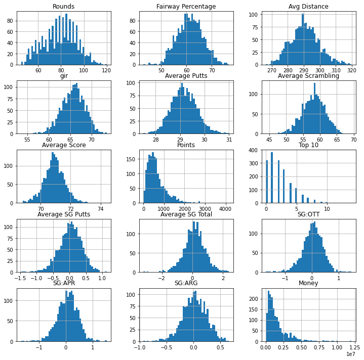

```python
fig, ax1 = plt.subplots(5,3, figsize=(12,12))

numdata.hist(bins=50, ax=ax1)
```

### Correlation Heatmap

I used a slightly different method than I typically would for creating a heatmap because I wanted to make sure the cmap was centered from -1 to 1. This ensures we aren't misled by certain parts of the heatmap being darker than they should be.

[output not shown]

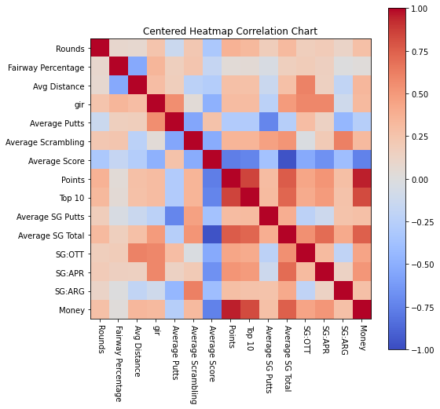

```python
plt.figure(figsize=(8, 8))

corr = numdata.corr()
plt.imshow(corr, cmap='coolwarm', interpolation='nearest',vmin=-1,vmax=1)

plt.colorbar()

plt.title('Centered Heatmap Correlation Chart')
plt.xticks(range(len(corr)), corr.columns, rotation=270)
plt.yticks(range(len(corr)), corr.index)
```

### Find the correlation coefficient compared to our target

Looking at the correlation coefficients below, we can notice that Points and Money have a strong correlation to number of wins. Surprisingly, Average Score and Top 10s don't have quite as strong of a correlation.

```python
df.corr()['Wins']
```

```
Rounds                0.103162
Fairway Percentage   -0.047949
Year                  0.039006
Avg Distance          0.206294
gir                   0.120340
Average Putts        -0.168764
Average Scrambling    0.125193
Average Score        -0.390254
Points                0.750110
Wins                  1.000000
Top 10                0.473453
Average SG Putts      0.149155
Average SG Total      0.384932
SG:OTT                0.232414
SG:APR                0.259363
SG:ARG                0.134948
Money                 0.721665
Name: Wins, dtype: float64
```

### Add a winner column

After all, we aren't prediciting how many wins a player had, only if he won or not. Therefore, I created a Winner column using apply and lambda functions. If the wins variable has 1 or more then the Winner column will have a 1. Otherwise, it will have a 0

```python
#Add winner column
df['Winner'] = df['Wins'].apply(lambda x: 1 if x>0 else 0)
y = df['Winner']

X = df.copy()
X.drop(['Player Name', 'Wins', 'Winner'], axis = 1, inplace=True)
X.head()
```

|  | Rounds | Fairway Percentage | Year | Avg Distance | gir | Average Putts | Average Scrambling | Average Score | Points | Top 10 | Average SG Putts | Average SG Total | SG:OTT | SG:APR | SG:ARG | Money |
| --- | --- | --- | --- | --- | --- | --- | --- | --- | --- | --- | --- | --- | --- | --- | --- | --- |
| 0 | 60 | 75.19 | 2018 | 291.5 | 73.51 | 29.93 | 60.67 | 69.617 | 868 | 5 | -0.207 | 1.153 | 0.427 | 0.960 | -0.027 | 2680487.0 |
| 1 | 109 | 73.58 | 2018 | 283.5 | 68.22 | 29.31 | 60.13 | 70.758 | 1006 | 3 | -0.058 | 0.337 | -0.012 | 0.213 | 0.194 | 2485203.0 |
| 2 | 93 | 72.24 | 2018 | 286.5 | 68.67 | 29.12 | 62.27 | 70.432 | 1020 | 3 | 0.192 | 0.674 | 0.183 | 0.437 | -0.137 | 2700018.0 |
| 3 | 78 | 71.94 | 2018 | 289.2 | 68.80 | 29.17 | 64.16 | 70.015 | 795 | 5 | -0.271 | 0.941 | 0.406 | 0.532 | 0.273 | 1986608.0 |
| 4 | 103 | 71.44 | 2018 | 278.9 | 67.12 | 29.11 | 59.23 | 71.038 | 421 | 3 | 0.164 | 0.062 | -0.227 | 0.099 | 0.026 | 1089763.0 |

## Train/Test Split

```python
from sklearn.model_selection import train_test_split, cross_val_score

X_train, X_test, y_train, y_test = train_test_split(X, y, random_state = 42)
```

## Support Vector Machine Model

First off, we will try an SVM Liner Model and see how it performs.

```python
from sklearn.svm import SVC
from sklearn.preprocessing import StandardScaler
from sklearn.metrics import accuracy_score, classification_report, confusion_matrix, roc_curve, auc
```

```python
scaler = StandardScaler()
X_train_scaled = scaler.fit_transform(X_train)
X_test_scaled = scaler.transform(X_test)
```

```python
svm_model = SVC(kernel='linear', random_state=42)
svm_model.fit(X_train_scaled, y_train)
```

```
SVC(kernel='linear', random_state=42)
```

```python
y_pred = svm_model.predict(X_test_scaled)
```

```python
accuracy = accuracy_score(y_test, y_pred)
conf_matrix = confusion_matrix(y_test, y_pred)
classification_rep = classification_report(y_test, y_pred)

print('SVM accuracy on training set: {:.2f}'.format(svm_model.score(X_train_scaled, y_train)))
print(f'SVM accuracy on testing set: {accuracy:.2f}')
print(f'Confusion Matrix:\n{conf_matrix}')
print(f'Classification Report:\n{classification_rep}')
```

```
SVM accuracy on training set: 0.94
SVM accuracy on testing set: 0.94
Confusion Matrix:
[[333  10]
 [ 14  62]]
Classification Report:
              precision    recall  f1-score   support

           0       0.96      0.97      0.97       343
           1       0.86      0.82      0.84        76

    accuracy                           0.94       419
   macro avg       0.91      0.89      0.90       419
weighted avg       0.94      0.94      0.94       419
```

### Performance of Initial SVM Model and Hyperparameter Tuning

- The accuracy for the initial model was 94%. That's pretty decent for a first try. 395 out of 419 were predicted correctly! Let's see if we can improve that at all
- Using grid search I entered a few possible parameters to see if we can improve our model.
  - First I entered a few different values for the regularization parameter 'C'. The default for this value is 1, but I wanted to test out 0.1, 1, 10, and 100. The higher the value, the less outliers we are allowing.
  - Next, I entered 3 kernel types to be used in the algorithm. I originally, had linear as the kernel but added polynomial and radial basis function.
- The best model given the parameters attemped only changed the regularization parameter. The default value is 1, but the best svm model was 10. This improved our accuracy to 95% and 396 out of 419. Ultimately, a very similar model to the original.

```python
from sklearn.model_selection import GridSearchCV

param_grid = {'C': [0.1, 1, 10, 100], 'kernel': ['linear', 'poly', 'rbf']}
grid_search = GridSearchCV(SVC(random_state=42), param_grid, cv=5)
grid_search.fit(X_train_scaled, y_train)

best_svm_model = grid_search.best_estimator_
print(best_svm_model)
```

```
SVC(C=10, kernel='linear', random_state=42)
```

```python
best_svm_model.fit(X_train_scaled, y_train)
```

```
SVC(C=10, kernel='linear', random_state=42)
```

```python
y_pred = best_svm_model.predict(X_test_scaled)

test_accuracy = accuracy_score(y_test, y_pred)
conf_matrix = confusion_matrix(y_test, y_pred)
classification_rep = classification_report(y_test, y_pred)

print('SVM accuracy on training set: {:.2f}'.format(best_svm_model.score(X_train_scaled, y_train)))
print(f'SVM accuracy on testing set: {test_accuracy:.2f}')
print(f'Confusion Matrix:\n{conf_matrix}')
print(f'Classification Report:\n{classification_rep}')
```

```
SVM accuracy on training set: 0.95
SVM accuracy on testing set: 0.95
Confusion Matrix:
[[335   8]
 [ 15  61]]
Classification Report:
              precision    recall  f1-score   support

           0       0.96      0.98      0.97       343
           1       0.88      0.80      0.84        76

    accuracy                           0.95       419
   macro avg       0.92      0.89      0.90       419
weighted avg       0.94      0.95      0.94       419
```

## Random Forest

Considering the data that I am working with, SVM will be pretty hard to beat, but I wanted to try using a Random Forest. We'll start off with just a default RandomForestRegressor.

```python
from sklearn.ensemble import RandomForestRegressor

model = RandomForestRegressor(random_state=42)
model.fit(X_train, y_train)
```

```
RandomForestRegressor(random_state=42)
```

After looking at the accuracy scores below. We can see that the accuracy on the training set was far better than the testing set, leading me to believe that we have overfit our model to the training data.

```python
y_pred = model.predict(X_test)

print('Random Forest accuracy on training set: {:.2f}'.format(model.score(X_train, y_train)))
print('Random Forest accuracy on testing set: {:.2f}'.format(model.score(X_test, y_test)))
```

```
Random Forest accuracy on training set: 0.95
Random Forest accuracy on testing set: 0.63
```

### Hyperparameter Tuning for Random Forest

Even though, Random Forest Regression might not be the best model for predicting 1s and 0s, let's try some hyperparamter tuning to see what happens.

I added 50, 100 and 200 for the number of trees in the forest. The default value is 100. Then, I added None, 10 and 20 to the max depth of the tree. The default value for max_depth is None.

```python
param_grid = {
    'n_estimators': [50,100,200],
    'max_depth': [None, 10, 20]
}

tuned_model = RandomForestRegressor()

grid_search = GridSearchCV(estimator=tuned_model, param_grid=param_grid, cv=5, scoring='neg_mean_squared_error')
grid_search.fit(X_train, y_train)

best_rf_model = grid_search.best_estimator_
best_rf_model.fit(X_train, y_train)
```

```
RandomForestRegressor(max_depth=20, n_estimators=200)
```

The best Random Forest model has a max_depth of 20 and 200 estimators. This is slightly different from the default regressor, but yields us very similar results. Using a Random Forest on this type of data just isn't a very good fit.

```python
y_pred = best_rf_model.predict(X_test)

print('Random Forest accuracy on training set: {:.2f}'.format(best_rf_model.score(X_train, y_train)))
print('Random Forest accuracy on testing set: {:.2f}'.format(best_rf_model.score(X_test, y_test)))
print(cross_val_score(best_rf_model, X, y, cv=5))
```

```
Random Forest accuracy on training set: 0.95
Random Forest accuracy on testing set: 0.64
[0.56769988 0.59083215 0.67784789 0.70126431 0.57970926]
```

## Logistic Regression

```python
from sklearn.linear_model import LogisticRegression

logreg_model = LogisticRegression(random_state=42)
logreg_model.fit(X_train, y_train)
```

```
LogisticRegression(random_state=42)
```

```python
y_pred = logreg_model.predict(X_test)
```

```python
test_accuracy = accuracy_score(y_test, y_pred)
conf_matrix = confusion_matrix(y_test, y_pred)
classification_rep = classification_report(y_test, y_pred)

print(cross_val_score(logreg_model, X, y, cv=5))
print('Logistic Regression accuracy on training set: {:.2f}'.format(logreg_model.score(X_train, y_train)))
print(f'Logistic Regression accuracy on testing set: {test_accuracy:.2f}')
print(f'Confusion Matrix:\n{conf_matrix}')
print(f'Classification Report:\n{classification_rep}')
```

```
[0.89850746 0.89552239 0.89850746 0.92835821 0.9011976 ]
Logistic Regression accuracy on training set: 0.91
Logistic Regression accuracy on testing set: 0.90
Confusion Matrix:
[[335   8]
 [ 33  43]]
Classification Report:
              precision    recall  f1-score   support

           0       0.91      0.98      0.94       343
           1       0.84      0.57      0.68        76

    accuracy                           0.90       419
   macro avg       0.88      0.77      0.81       419
weighted avg       0.90      0.90      0.89       419
```

### Hyperparameter training for Logistic Regression

Adjusting the regularization parameter to see if we can improve our model

```python
best_log_reg_model = LogisticRegression()

param_grid = {
    'C': [0.001, 0.01, 0.1, 1, 10, 100]
}

grid_search = GridSearchCV(best_log_reg_model, param_grid, cv=5, scoring='accuracy')

grid_search.fit(X_train, y_train)

grid_search.best_params_
```

```
{'C': 0.001}
```

```python
best_model = grid_search.best_estimator_

y_pred = best_model.predict(X_test)
```

```python
test_accuracy = accuracy_score(y_test, y_pred)
conf_matrix = confusion_matrix(y_test, y_pred)
classification_rep = classification_report(y_test, y_pred)

print(cross_val_score(best_model, X, y, cv=5))
print('Logistic Regression accuracy on training set: {:.2f}'.format(best_model.score(X_train, y_train)))
print(f'Logistic Regression accuracy on testing set: {test_accuracy:.2f}')
print(f'Confusion Matrix:\n{conf_matrix}')
print(f'Classification Report:\n{classification_rep}')
```

```
[0.89850746 0.89552239 0.89850746 0.92835821 0.9011976 ]
Logistic Regression accuracy on training set: 0.90
Logistic Regression accuracy on testing set: 0.90
Confusion Matrix:
[[334   9]
 [ 33  43]]
Classification Report:
              precision    recall  f1-score   support

           0       0.91      0.97      0.94       343
           1       0.83      0.57      0.67        76

    accuracy                           0.90       419
   macro avg       0.87      0.77      0.81       419
weighted avg       0.89      0.90      0.89       419
```

## Future Projects

While I did put a lot of effort into this project, I feel like there is much more to be explored. It is a really interesting dataset. One thing I would like to look further into is creating models to predict how much money a player made in a given year. This may be difficult because the prize values aren't linear to score. Rather, they are based on what place the player finishes. For example, if a player loses by 10 shots, but gets 2nd they still win a huge amount of money. Nonetheless, it's a challenge that I would love to take on.

Also, one thing I know I need to improve on is learning more about the different types of models. With that knowledge, I would be able to make better selections given the data that I am working with.

Lastly, I want to learn a good way to display a plot for the regression models when the target is a boolean value.

This project has provided the ground work for me to improve upon my base level skills and apply them to bigger and better future projects.